# HOMEWORK 3 - Creating Value Through Data Mining (S402010)

Liam Phan

2022-11-11

# Loading Packages

## Loading Packages

```r
library(data.table) # Efficient Dataframe
library(lubridate) # For Dates
library(tidyverse) # Multiple Package for Useful Data wrangling
library(esquisse) # Intuitive plotting
library(plyr) # Data splitting
library(dplyr) # Data Wrangling
library(ggplot2) # Plot Graphs
library(naniar) # for NA exploration in Dataframe
library(plotly) # Make ggplot2 Dynamic
library(gridExtra) # Multiple Plot at once
library(RColorBrewer) # For Color Palette
library(rmdformats) # Theme of HTML
library(flextable) # Show Table
library(class) # K-NN
library(summarytools) # Beautiful and Efficient Summary for Dataset
library(pivottabler) # Pivot Table
library(naivebayes) # Naive Bayes Function
library(caret) # Confusion Matrix
library(leaps) # Exhaustive Search
library(forecast) # Predictions
library(neuralnet) # Neural Network
library(nnet) # Neural Network
```

# Dataset Preparation

## Loading the dataset called “ToyotaCorolla.csv”

```r
# Load the Dataset with Fread()
ToyotaDT <- fread("DATA/ToyotaCorolla.csv")
```

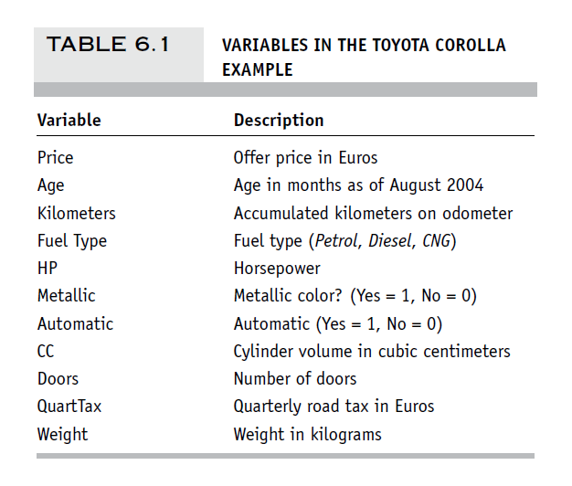

## Quick Preview

```r
# Preview of the Dataset
flextable(head(ToyotaDT,2)) %>% fontsize(size = 8, part = "all")
```

| Id | Model | Price | Age_08_04 | Mfg_Month | Mfg_Year | KM | Fuel_Type | HP | Met_Color | Color | Automatic | CC | Doors | Cylinders | Gears | Quarterly_Tax | Weight | Mfr_Guarantee | BOVAG_Guarantee | Guarantee_Period | ABS | Airbag_1 | Airbag_2 | Airco | Automatic_airco | Boardcomputer | CD_Player | Central_Lock | Powered_Windows | … |
| --- | --- | --- | --- | --- | --- | --- | --- | --- | --- | --- | --- | --- | --- | --- | --- | --- | --- | --- | --- | --- | --- | --- | --- | --- | --- | --- | --- | --- | --- | --- |
| 1 | TOYOTA Corolla 2.0 D4D HATCHB TERRA 2/3-Doors | 13,500 | 23 | 10 | 2,002 | 46,986 | Diesel | 90 | 1 | Blue | 0 | 2,000 | 3 | 4 | 5 | 210 | 1,165 | 0 | 1 | 3 | 1 | 1 | 1 | 0 | 0 | 1 | 0 | 1 | 1 | … |
| 2 | TOYOTA Corolla 2.0 D4D HATCHB TERRA 2/3-Doors | 13,750 | 23 | 10 | 2,002 | 72,937 | Diesel | 90 | 1 | Silver | 0 | 2,000 | 3 | 4 | 5 | 210 | 1,165 | 0 | 1 | 3 | 1 | 1 | 1 | 1 | 0 | 1 | 1 | 1 | 0 | … |

> Dataset Description: The file ToyotaCorolla.csv contains data on used cars on sale during late summer of 2004 in the Netherlands. It has 1436 records containing detail on 38 attributes, including Price, Age, Kilometers, HP (Horse Power), and other specifications.

```r
dfSummary(ToyotaDT,
          plain.ascii  = FALSE,
          style        = "grid",
          graph.magnif = 0.75,
          valid.col    = FALSE,
          tmp.img.dir  = "/tmp")
```

### Data Frame Summary

#### ToyotaDT

**Dimensions:** 1436 x 39  
**Duplicates:** 0

| No | Variable | Stats / Values | Freqs (% of Valid) | Graph | Missing |
| --- | --- | --- | --- | --- | --- |
| 1 | Id [integer] | Mean (sd) : 721.6 (416.5) min < med < max: 1 < 721.5 < 1442 IQR (CV) : 719.5 (0.6) | 1436 distinct values |  | 0 (0.0%) |
| 2 | Model [character] | 1. TOYOTA Corolla 1.6 16V HA 2. TOYOTA Corolla 1.3 16V HA 3. TOYOTA Corolla 1.6 16V LI 4. TOYOTA Corolla 1.6 16V LI 5. TOYOTA Corolla 1.6 16V SE 6. TOYOTA Corolla 1.4 16V VV 7. TOYOTA Corolla 1.3 16V … | 107 ( 7.5%) 83 ( 5.8%) 79 ( 5.5%) 70 ( 4.9%) 43 ( 3.0%) 42 ( 2.9%) 35 ( 2.4%) 31 ( 2.2%) 28 ( 1.9%) 27 ( 1.9%) 891 (62.0%) |  | 0 (0.0%) |
| 3 | Price [integer] | Mean (sd) : 10730.8 (3627) min < med < max: 4350 < 9900 < 32500 IQR (CV) : 3500 (0.3) | 236 distinct values |  | 0 (0.0%) |
| 4 | Age_08_04 [integer] | Mean (sd) : 55.9 (18.6) min < med < max: 1 < 61 < 80 IQR (CV) : 26 (0.3) | 77 distinct values |  | 0 (0.0%) |
| 5 | Mfg_Month [integer] | Mean (sd) : 5.5 (3.4) min < med < max: 1 < 5 < 12 IQR (CV) : 5 (0.6) | 12 distinct values |  | 0 (0.0%) |
| 6 | Mfg_Year [integer] | Mean (sd) : 1999.6 (1.5) min < med < max: 1998 < 1999 < 2004 IQR (CV) : 3 (0) | 1998 : 392 (27.3%) 1999 : 441 (30.7%) 2000 : 225 (15.7%) 2001 : 192 (13.4%) 2002 : 87 ( 6.1%) 2003 : 75 ( 5.2%) 2004 : 24 ( 1.7%) |  | 0 (0.0%) |
| 7 | KM [integer] | Mean (sd) : 68533.3 (37506.4) min < med < max: 1 < 63389.5 < 243000 IQR (CV) : 44020.8 (0.5) | 1263 distinct values |  | 0 (0.0%) |
| 8 | Fuel_Type [character] | 1. CNG 2. Diesel 3. Petrol | 17 ( 1.2%) 155 (10.8%) 1264 (88.0%) |  | 0 (0.0%) |
| 9 | HP [integer] | Mean (sd) : 101.5 (15) min < med < max: 69 < 110 < 192 IQR (CV) : 20 (0.1) | 12 distinct values |  | 0 (0.0%) |
| 10 | Met_Color [integer] | Min : 0 Mean : 0.7 Max : 1 | 0 : 467 (32.5%) 1 : 969 (67.5%) |  | 0 (0.0%) |
| 11 | Color [character] | 1. Beige 2. Black 3. Blue 4. Green 5. Grey 6. Red 7. Silver 8. Violet 9. White 10. Yellow | 3 ( 0.2%) 191 (13.3%) 283 (19.7%) 220 (15.3%) 301 (21.0%) 278 (19.4%) 122 ( 8.5%) 4 ( 0.3%) 31 ( 2.2%) 3 ( 0.2%) |  | 0 (0.0%) |
| 12 | Automatic [integer] | Min : 0 Mean : 0.1 Max : 1 | 0 : 1356 (94.4%) 1 : 80 ( 5.6%) |  | 0 (0.0%) |
| 13 | CC [integer] | Mean (sd) : 1576.9 (424.4) min < med < max: 1300 < 1600 < 16000 IQR (CV) : 200 (0.3) | 13 distinct values |  | 0 (0.0%) |
| 14 | Doors [integer] | Mean (sd) : 4 (1) min < med < max: 2 < 4 < 5 IQR (CV) : 2 (0.2) | 2 : 2 ( 0.1%) 3 : 622 (43.3%) 4 : 138 ( 9.6%) 5 : 674 (46.9%) |  | 0 (0.0%) |
| 15 | Cylinders [integer] | 1 distinct value | 4 : 1436 (100.0%) |  | 0 (0.0%) |
| 16 | Gears [integer] | Mean (sd) : 5 (0.2) min < med < max: 3 < 5 < 6 IQR (CV) : 0 (0) | 3 : 2 ( 0.1%) 4 : 1 ( 0.1%) 5 : 1390 (96.8%) 6 : 43 ( 3.0%) |  | 0 (0.0%) |
| 17 | Quarterly_Tax [integer] | Mean (sd) : 87.1 (41.1) min < med < max: 19 < 85 < 283 IQR (CV) : 16 (0.5) | 13 distinct values |  | 0 (0.0%) |
| 18 | Weight [integer] | Mean (sd) : 1072.5 (52.6) min < med < max: 1000 < 1070 < 1615 IQR (CV) : 45 (0) | 59 distinct values |  | 0 (0.0%) |
| 19 | Mfr_Guarantee [integer] | Min : 0 Mean : 0.4 Max : 1 | 0 : 848 (59.1%) 1 : 588 (40.9%) |  | 0 (0.0%) |
| 20 | BOVAG_Guarantee [integer] | Min : 0 Mean : 0.9 Max : 1 | 0 : 150 (10.4%) 1 : 1286 (89.6%) |  | 0 (0.0%) |
| 21 | Guarantee_Period [integer] | Mean (sd) : 3.8 (3) min < med < max: 3 < 3 < 36 IQR (CV) : 0 (0.8) | 3 : 1274 (88.7%) 6 : 77 ( 5.4%) 12 : 73 ( 5.1%) 13 : 1 ( 0.1%) 18 : 1 ( 0.1%) 20 : 1 ( 0.1%) 24 : 4 ( 0.3%) 28 : 1 ( 0.1%) 36 : 4 ( 0.3%) |  | 0 (0.0%) |
| 22 | ABS [integer] | Min : 0 Mean : 0.8 Max : 1 | 0 : 268 (18.7%) 1 : 1168 (81.3%) |  | 0 (0.0%) |
| 23 | Airbag_1 [integer] | Min : 0 Mean : 1 Max : 1 | 0 : 42 ( 2.9%) 1 : 1394 (97.1%) |  | 0 (0.0%) |
| 24 | Airbag_2 [integer] | Min : 0 Mean : 0.7 Max : 1 | 0 : 398 (27.7%) 1 : 1038 (72.3%) |  | 0 (0.0%) |
| 25 | Airco [integer] | Min : 0 Mean : 0.5 Max : 1 | 0 : 706 (49.2%) 1 : 730 (50.8%) |  | 0 (0.0%) |
| 26 | Automatic_airco [integer] | Min : 0 Mean : 0.1 Max : 1 | 0 : 1355 (94.4%) 1 : 81 ( 5.6%) |  | 0 (0.0%) |
| 27 | Boardcomputer [integer] | Min : 0 Mean : 0.3 Max : 1 | 0 : 1013 (70.5%) 1 : 423 (29.5%) |  | 0 (0.0%) |
| 28 | CD_Player [integer] | Min : 0 Mean : 0.2 Max : 1 | 0 : 1122 (78.1%) 1 : 314 (21.9%) |  | 0 (0.0%) |
| 29 | Central_Lock [integer] | Min : 0 Mean : 0.6 Max : 1 | 0 : 603 (42.0%) 1 : 833 (58.0%) |  | 0 (0.0%) |
| 30 | Powered_Windows [integer] | Min : 0 Mean : 0.6 Max : 1 | 0 : 629 (43.8%) 1 : 807 (56.2%) |  | 0 (0.0%) |
| 31 | Power_Steering [integer] | Min : 0 Mean : 1 Max : 1 | 0 : 32 ( 2.2%) 1 : 1404 (97.8%) |  | 0 (0.0%) |
| 32 | Radio [integer] | Min : 0 Mean : 0.1 Max : 1 | 0 : 1226 (85.4%) 1 : 210 (14.6%) |  | 0 (0.0%) |
| 33 | Mistlamps [integer] | Min : 0 Mean : 0.3 Max : 1 | 0 : 1067 (74.3%) 1 : 369 (25.7%) |  | 0 (0.0%) |
| 34 | Sport_Model [integer] | Min : 0 Mean : 0.3 Max : 1 | 0 : 1005 (70.0%) 1 : 431 (30.0%) |  | 0 (0.0%) |
| 35 | Backseat_Divider [integer] | Min : 0 Mean : 0.8 Max : 1 | 0 : 330 (23.0%) 1 : 1106 (77.0%) |  | 0 (0.0%) |
| 36 | Metallic_Rim [integer] | Min : 0 Mean : 0.2 Max : 1 | 0 : 1142 (79.5%) 1 : 294 (20.5%) |  | 0 (0.0%) |
| 37 | Radio_cassette [integer] | Min : 0 Mean : 0.1 Max : 1 | 0 : 1227 (85.4%) 1 : 209 (14.6%) |  | 0 (0.0%) |
| 38 | Parking_Assistant [integer] | Min : 0 Mean : 0 Max : 1 | 0 : 1432 (99.7%) 1 : 4 ( 0.3%) |  | 0 (0.0%) |
| 39 | Tow_Bar [integer] | Min : 0 Mean : 0.3 Max : 1 | 0 : 1037 (72.2%) 1 : 399 (27.8%) |  | 0 (0.0%) |

## Missing Variables Plot

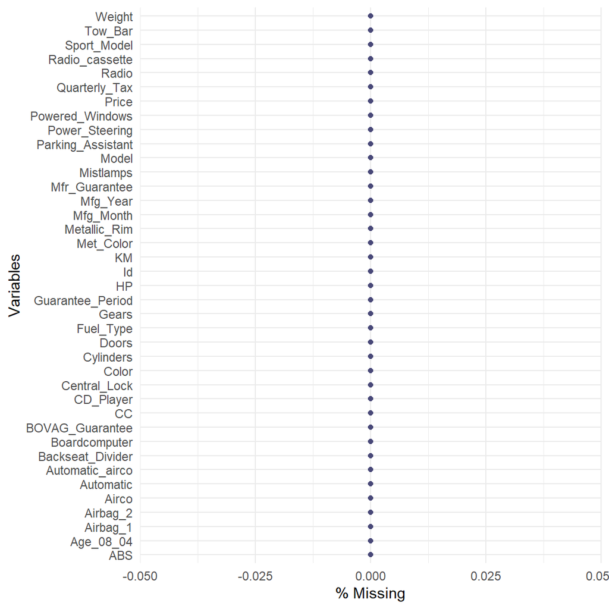

```r
# Missing Variables Plot for the Dataset
gg_miss_var(ToyotaDT, show_pct = TRUE)
```

> We can see that there is no missing values in our dataset ToyotaCorolla.csv

# Ex 6.4

## Predicting Prices of Used Cars

Split the data into training (50%), validation (30%), and test (20%) datasets.

```r
# Setting Seed
set.seed(1)

# Splitting Training and Validation and Test
splitting <- sample(1:3,size=nrow(ToyotaDT),replace=TRUE,prob=c(0.5,0.3,0.2))
Training <- ToyotaDT[splitting==1,]
Validation <- ToyotaDT[splitting==2,]
Test <- ToyotaDT[splitting==3,]

# Checking if proportions are right
Prop_Training <- (nrow(Training)/nrow(ToyotaDT))*100
Prop_Validation <- (nrow(Validation)/nrow(ToyotaDT))*100
Prop_Test <- (nrow(Test)/nrow(ToyotaDT))*100

# Print Proportion
paste("The Proportions are:", round(Prop_Training,2),"% In Training,",round(Prop_Validation,2),"% In Validation, and ",round(Prop_Test,2),"% In Test")
```

[1] “The Proportions are: 52.58 % In Training, 27.79 % In Validation, and 19.64 % In Test”

### Run a multiple linear regression

with the outcome variable **Price** and predictor variables **Age_08**, **KM**, **Fuel_Type**, **HP**, **Automatic**, **Doors**, **Quarterly_Tax**, **Mfr_Guarantee**, **Guarantee_Period**, **Airco**, **Automatic_airco**, **CD_Player**, **Powered_Windows**, **Sport_Model**, and **Tow_Bar**.

### Outcome Variable

> **Numerical**: Price

### Explanatory Variables

> **Numerical**: Age_08, KM, HP, Doors, Quarterly_Tax, Quarantee_Period

> **Categorical/Dummy**: Fuel Type, Automatic, Mfr_Guarantee, Airco, Automatic_airco, CD_Player, Powered Windows, Sport_Model, Tow_Bar

### Running the Linear Regression

```r
# Linear OLS Regression on Training
Regression_Price <- lm(Price ~ Age_08_04 + KM + Fuel_Type + HP + Automatic + Doors + Quarterly_Tax + Mfr_Guarantee + Guarantee_Period + Airco + Automatic_airco + CD_Player + Powered_Windows + Sport_Model + Tow_Bar, data = Training)

# Scientific Notation
options(scipen = 999)

summary(Regression_Price)
```

```
FALSE
FALSE Call:
FALSE lm(formula = Price ~ Age_08_04 + KM + Fuel_Type + HP + Automatic +
FALSE     Doors + Quarterly_Tax + Mfr_Guarantee + Guarantee_Period +
FALSE     Airco + Automatic_airco + CD_Player + Powered_Windows + Sport_Model +
FALSE     Tow_Bar, data = Training)
FALSE
FALSE Residuals:
FALSE     Min      1Q  Median      3Q     Max
FALSE -4605.0  -725.0    26.5   655.5  5567.0
FALSE
FALSE Coefficients:
FALSE                      Estimate   Std. Error t value             Pr(>|t|)
FALSE (Intercept)      10149.303878   753.570928  13.468 < 0.0000000000000002 ***
FALSE Age_08_04         -106.254953     3.648627 -29.122 < 0.0000000000000002 ***
FALSE KM                  -0.018110     0.001693 -10.697 < 0.0000000000000002 ***
FALSE Fuel_TypeDiesel   1775.761977   509.701393   3.484             0.000523 ***
FALSE Fuel_TypePetrol   2087.180327   530.110397   3.937   0.0000902216317796 ***
FALSE HP                  26.355347     3.846774   6.851   0.0000000000154436 ***
FALSE Automatic          605.249517   178.506754   3.391             0.000734 ***
FALSE Doors              153.627129    46.146978   3.329             0.000915 ***
FALSE Quarterly_Tax       16.814925     2.081831   8.077   0.0000000000000027 ***
FALSE Mfr_Guarantee      125.684485    91.024994   1.381             0.167768
FALSE Guarantee_Period    72.439768    15.661721   4.625   0.0000044171894508 ***
FALSE Airco              175.868563   106.848246   1.646             0.100197
FALSE Automatic_airco   3178.052845   209.461203  15.173 < 0.0000000000000002 ***
FALSE CD_Player          247.920668   120.057343   2.065             0.039270 *
FALSE Powered_Windows    426.529261   103.224416   4.132   0.0000400718888028 ***
FALSE Sport_Model        268.489425    98.070812   2.738             0.006336 **
FALSE Tow_Bar           -250.505084    97.621305  -2.566             0.010481 *
FALSE ---
FALSE Signif. codes:  0 '***' 0.001 '**' 0.01 '*' 0.05 '.' 0.1 ' ' 1
FALSE
FALSE Residual standard error: 1155 on 738 degrees of freedom
FALSE Multiple R-squared:  0.8915,  Adjusted R-squared:  0.8891
FALSE F-statistic: 378.8 on 16 and 738 DF,  p-value: < 0.00000000000000022
```

> Taking into account all the requested variables in our linear regression without further analysis or variable selection, we can observe a fairly high Multiple R-squared, close to 0.8915 and a fit of 0.8891. We have a very significant F-statistic, close to 0 which means that this model is already quite complex and better than a naive model including only the intercept. The most significant variables are the **Age** of the car, the number of kilometres (**KM**) and the automatic air conditioning (**Automatic_airco**), since all have the smallest p-value.

### 1. Exhaustive Search

```r
# use regsubsets() in package leaps to run an exhaustive search.
library(leaps)

# Duplicate the Dataset Training for Modification of Dummy
Training_Search <- Training

# create dummies for fuel type
Fuel_Type <- as.data.frame(model.matrix(~ 0 + Fuel_Type, data=Training_Search))

# replace Fuel_Type column with 2 dummies
Training_Search <- cbind(Training_Search[,-8], Fuel_Type[,])

# Search
search <- regsubsets(Price ~ Age_08_04 + KM + Fuel_TypeCNG + Fuel_TypeDiesel + Fuel_TypePetrol + HP + Automatic + Doors + Quarterly_Tax + Mfr_Guarantee + Guarantee_Period + Airco + Automatic_airco + CD_Player + Powered_Windows + Sport_Model + Tow_Bar, data = Training_Search, nbest = 1, nvmax = dim(Training_Search)[2],
method = "exhaustive")
```

```
FALSE Reordering variables and trying again:
```

```r
sum <- summary(search)
```

### Show Models

```r
# show models
sum$which
```

```
FALSE    (Intercept) Age_08_04    KM Fuel_TypeCNG Fuel_TypeDiesel Fuel_TypePetrol
FALSE 1         TRUE      TRUE FALSE        FALSE           FALSE           FALSE
FALSE 2         TRUE      TRUE FALSE        FALSE           FALSE           FALSE
FALSE 3         TRUE      TRUE  TRUE        FALSE           FALSE           FALSE
FALSE 4         TRUE      TRUE  TRUE        FALSE           FALSE           FALSE
FALSE 5         TRUE      TRUE  TRUE        FALSE           FALSE           FALSE
FALSE 6         TRUE      TRUE  TRUE        FALSE           FALSE           FALSE
FALSE 7         TRUE      TRUE  TRUE        FALSE           FALSE           FALSE
FALSE 8         TRUE      TRUE  TRUE         TRUE           FALSE           FALSE
FALSE 9         TRUE      TRUE  TRUE         TRUE           FALSE           FALSE
FALSE 10        TRUE      TRUE  TRUE         TRUE           FALSE           FALSE
FALSE 11        TRUE      TRUE  TRUE         TRUE           FALSE           FALSE
FALSE 12        TRUE      TRUE  TRUE         TRUE           FALSE           FALSE
FALSE 13        TRUE      TRUE  TRUE         TRUE           FALSE           FALSE
FALSE 14        TRUE      TRUE  TRUE         TRUE           FALSE           FALSE
FALSE 15        TRUE      TRUE  TRUE         TRUE           FALSE           FALSE
FALSE 16        TRUE      TRUE  TRUE         TRUE            TRUE           FALSE
FALSE       HP Automatic Doors Quarterly_Tax Mfr_Guarantee Guarantee_Period Airco
FALSE 1  FALSE     FALSE FALSE         FALSE         FALSE            FALSE FALSE
FALSE 2  FALSE     FALSE FALSE         FALSE         FALSE            FALSE FALSE
FALSE 3  FALSE     FALSE FALSE         FALSE         FALSE            FALSE FALSE
FALSE 4  FALSE     FALSE FALSE          TRUE         FALSE            FALSE FALSE
FALSE 5   TRUE     FALSE FALSE          TRUE         FALSE            FALSE FALSE
FALSE 6   TRUE     FALSE FALSE          TRUE         FALSE            FALSE FALSE
FALSE 7   TRUE     FALSE FALSE          TRUE         FALSE             TRUE FALSE
FALSE 8   TRUE     FALSE FALSE          TRUE         FALSE             TRUE FALSE
FALSE 9   TRUE      TRUE FALSE          TRUE         FALSE             TRUE FALSE
FALSE 10  TRUE      TRUE  TRUE          TRUE         FALSE             TRUE FALSE
FALSE 11  TRUE      TRUE  TRUE          TRUE         FALSE             TRUE FALSE
FALSE 12  TRUE      TRUE  TRUE          TRUE         FALSE             TRUE FALSE
FALSE 13  TRUE      TRUE  TRUE          TRUE         FALSE             TRUE FALSE
FALSE 14  TRUE      TRUE  TRUE          TRUE         FALSE             TRUE  TRUE
FALSE 15  TRUE      TRUE  TRUE          TRUE          TRUE             TRUE  TRUE
FALSE 16  TRUE      TRUE  TRUE          TRUE          TRUE             TRUE  TRUE
FALSE    Automatic_airco CD_Player Powered_Windows Sport_Model Tow_Bar
FALSE 1            FALSE     FALSE           FALSE       FALSE   FALSE
FALSE 2             TRUE     FALSE           FALSE       FALSE   FALSE
FALSE 3             TRUE     FALSE           FALSE       FALSE   FALSE
FALSE 4             TRUE     FALSE           FALSE       FALSE   FALSE
FALSE 5             TRUE     FALSE           FALSE       FALSE   FALSE
FALSE 6             TRUE     FALSE            TRUE       FALSE   FALSE
FALSE 7             TRUE     FALSE            TRUE       FALSE   FALSE
FALSE 8             TRUE     FALSE            TRUE       FALSE   FALSE
FALSE 9             TRUE     FALSE            TRUE       FALSE   FALSE
FALSE 10            TRUE     FALSE            TRUE       FALSE   FALSE
FALSE 11            TRUE     FALSE            TRUE        TRUE   FALSE
FALSE 12            TRUE     FALSE            TRUE        TRUE    TRUE
FALSE 13            TRUE      TRUE            TRUE        TRUE    TRUE
FALSE 14            TRUE      TRUE            TRUE        TRUE    TRUE
FALSE 15            TRUE      TRUE            TRUE        TRUE    TRUE
FALSE 16            TRUE      TRUE            TRUE        TRUE    TRUE
```

### R-Squared

```r
# show metrics
sum$rsq
```

```
FALSE  [1] 0.7655313 0.8300988 0.8503445 0.8620935 0.8759748 0.8801229 0.8822341
FALSE  [8] 0.8844385 0.8861651 0.8874965 0.8888897 0.8897505 0.8905682 0.8909579
FALSE [15] 0.8913048 0.8914512
```

> R-Squared keep increasing when we add more and more variables to the model, which is already expected since it doesn’t account for the number of parameter (no penalty)

### Adjusted R-Squared

```r
sum$adjr2
```

```
FALSE  [1] 0.7652199 0.8296470 0.8497467 0.8613580 0.8751469 0.8791614 0.8811305
FALSE  [8] 0.8831993 0.8847899 0.8859844 0.8872447 0.8879675 0.8886484 0.8888949
FALSE [15] 0.8890985 0.8890979
```

> Adjusted R-Squared keep increasing until the 15th value, 0.8890985 which is slight higher than the last one (16th).

### Cp

```r
sum$cp
```

```
FALSE  [1] 840.94284 404.55680 269.09689 191.32625  99.07820  72.91427  60.58056
FALSE  [8]  47.61333  37.89066  30.85073  23.39186  19.54705  15.99520  15.34962
FALSE [15]  14.99434  16.00000
```

### 2. Popular Subset Selection Algorithms

#### 2.1 Forward Selection

```r
# Setting Forward Selection
Regression_Price_Forward <- step(Regression_Price, direction = "forward")
```

```
FALSE Start:  AIC=10665.11
FALSE Price ~ Age_08_04 + KM + Fuel_Type + HP + Automatic + Doors +
FALSE     Quarterly_Tax + Mfr_Guarantee + Guarantee_Period + Airco +
FALSE     Automatic_airco + CD_Player + Powered_Windows + Sport_Model +
FALSE     Tow_Bar
```

```r
summary(Regression_Price_Forward)
```

```
FALSE
FALSE Call:
FALSE lm(formula = Price ~ Age_08_04 + KM + Fuel_Type + HP + Automatic +
FALSE     Doors + Quarterly_Tax + Mfr_Guarantee + Guarantee_Period +
FALSE     Airco + Automatic_airco + CD_Player + Powered_Windows + Sport_Model +
FALSE     Tow_Bar, data = Training)
FALSE
FALSE Residuals:
FALSE     Min      1Q  Median      3Q     Max
FALSE -4605.0  -725.0    26.5   655.5  5567.0
FALSE
FALSE Coefficients:
FALSE                      Estimate   Std. Error t value             Pr(>|t|)
FALSE (Intercept)      10149.303878   753.570928  13.468 < 0.0000000000000002 ***
FALSE Age_08_04         -106.254953     3.648627 -29.122 < 0.0000000000000002 ***
FALSE KM                  -0.018110     0.001693 -10.697 < 0.0000000000000002 ***
FALSE Fuel_TypeDiesel   1775.761977   509.701393   3.484             0.000523 ***
FALSE Fuel_TypePetrol   2087.180327   530.110397   3.937   0.0000902216317796 ***
FALSE HP                  26.355347     3.846774   6.851   0.0000000000154436 ***
FALSE Automatic          605.249517   178.506754   3.391             0.000734 ***
FALSE Doors              153.627129    46.146978   3.329             0.000915 ***
FALSE Quarterly_Tax       16.814925     2.081831   8.077   0.0000000000000027 ***
FALSE Mfr_Guarantee      125.684485    91.024994   1.381             0.167768
FALSE Guarantee_Period    72.439768    15.661721   4.625   0.0000044171894508 ***
FALSE Airco              175.868563   106.848246   1.646             0.100197
FALSE Automatic_airco   3178.052845   209.461203  15.173 < 0.0000000000000002 ***
FALSE CD_Player          247.920668   120.057343   2.065             0.039270 *
FALSE Powered_Windows    426.529261   103.224416   4.132   0.0000400718888028 ***
FALSE Sport_Model        268.489425    98.070812   2.738             0.006336 **
FALSE Tow_Bar           -250.505084    97.621305  -2.566             0.010481 *
FALSE ---
FALSE Signif. codes:  0 '***' 0.001 '**' 0.01 '*' 0.05 '.' 0.1 ' ' 1
FALSE
FALSE Residual standard error: 1155 on 738 degrees of freedom
FALSE Multiple R-squared:  0.8915,  Adjusted R-squared:  0.8891
FALSE F-statistic: 378.8 on 16 and 738 DF,  p-value: < 0.00000000000000022
```

#### 2.2 Backward Elimination

```r
# Setting Backward Selection
Regression_Price_Backward <- step(Regression_Price, direction = "backward")
```

```
FALSE Start:  AIC=10665.11
FALSE Price ~ Age_08_04 + KM + Fuel_Type + HP + Automatic + Doors +
FALSE     Quarterly_Tax + Mfr_Guarantee + Guarantee_Period + Airco +
FALSE     Automatic_airco + CD_Player + Powered_Windows + Sport_Model +
FALSE     Tow_Bar
FALSE
FALSE                    Df  Sum of Sq        RSS   AIC
FALSE - Mfr_Guarantee     1    2543346  987052419 10665
FALSE <none>                            984509073 10665
FALSE - Airco             1    3614140  988123213 10666
FALSE - CD_Player         1    5688678  990197751 10668
FALSE - Tow_Bar           1    8784301  993293374 10670
FALSE - Sport_Model       1    9998577  994507650 10671
FALSE - Doors             1   14784705  999293778 10674
FALSE - Automatic         1   15336383  999845456 10675
FALSE - Fuel_Type         2   20941946 1005451019 10677
FALSE - Powered_Windows   1   22776981 1007286054 10680
FALSE - Guarantee_Period  1   28538984 1013048057 10685
FALSE - HP                1   62619200 1047128273 10710
FALSE - Quarterly_Tax     1   87028661 1071537733 10727
FALSE - KM                1  152653191 1137162264 10772
FALSE - Automatic_airco   1  307099000 1291608073 10868
FALSE - Age_08_04         1 1131365100 2115874173 11241
FALSE
FALSE Step:  AIC=10665.05
FALSE Price ~ Age_08_04 + KM + Fuel_Type + HP + Automatic + Doors +
FALSE     Quarterly_Tax + Guarantee_Period + Airco + Automatic_airco +
FALSE     CD_Player + Powered_Windows + Sport_Model + Tow_Bar
FALSE
FALSE                    Df  Sum of Sq        RSS   AIC
FALSE <none>                            987052419 10665
FALSE - Airco             1    3591518  990643937 10666
FALSE - CD_Player         1    6457971  993510389 10668
FALSE - Tow_Bar           1    8540281  995592700 10670
FALSE - Sport_Model       1    9978477  997030896 10671
FALSE - Doors             1   15120231 1002172650 10674
FALSE - Automatic         1   15145014 1002197433 10675
FALSE - Fuel_Type         2   22008962 1009061381 10678
FALSE - Powered_Windows   1   21946957 1008999375 10680
FALSE - Guarantee_Period  1   27250734 1014303152 10684
FALSE - HP                1   63791761 1050844179 10710
FALSE - Quarterly_Tax     1   91041143 1078093561 10730
FALSE - KM                1  154155059 1141207477 10773
FALSE - Automatic_airco   1  306222171 1293274589 10867
FALSE - Age_08_04         1 1146445473 2133497891 11245
```

```r
summary(Regression_Price_Backward)
```

```
FALSE
FALSE Call:
FALSE lm(formula = Price ~ Age_08_04 + KM + Fuel_Type + HP + Automatic +
FALSE     Doors + Quarterly_Tax + Guarantee_Period + Airco + Automatic_airco +
FALSE     CD_Player + Powered_Windows + Sport_Model + Tow_Bar, data = Training)
FALSE
FALSE Residuals:
FALSE     Min      1Q  Median      3Q     Max
FALSE -4582.7  -725.6    25.2   660.5  5528.3
FALSE
FALSE Coefficients:
FALSE                      Estimate   Std. Error t value             Pr(>|t|)
FALSE (Intercept)      10131.277848   753.919822  13.438 < 0.0000000000000002 ***
FALSE Age_08_04         -106.642999     3.640018 -29.297 < 0.0000000000000002 ***
FALSE KM                  -0.018189     0.001693 -10.743 < 0.0000000000000002 ***
FALSE Fuel_TypeDiesel   1771.331629   510.003814   3.473             0.000544 ***
FALSE Fuel_TypePetrol   2143.129536   528.883581   4.052 0.000056116325460097 ***
FALSE HP                  26.577649     3.845760   6.911 0.000000000010411626 ***
FALSE Automatic          601.387645   178.594281   3.367             0.000798 ***
FALSE Doors              155.306593    46.159231   3.365             0.000806 ***
FALSE Quarterly_Tax       17.108350     2.072226   8.256 0.000000000000000692 ***
FALSE Guarantee_Period    70.500818    15.608204   4.517 0.000007302497428398 ***
FALSE Airco              175.316066   106.913011   1.640             0.101472
FALSE Automatic_airco   3173.034931   209.558088  15.142 < 0.0000000000000002 ***
FALSE CD_Player          263.050250   119.629577   2.199             0.028196 *
FALSE Powered_Windows    417.921196   103.099161   4.054 0.000055786711372138 ***
FALSE Sport_Model        268.218889    98.130749   2.733             0.006421 **
FALSE Tow_Bar           -246.913474    97.646480  -2.529             0.011657 *
FALSE ---
FALSE Signif. codes:  0 '***' 0.001 '**' 0.01 '*' 0.05 '.' 0.1 ' ' 1
FALSE
FALSE Residual standard error: 1156 on 739 degrees of freedom
FALSE Multiple R-squared:  0.8912,  Adjusted R-squared:  0.889
FALSE F-statistic: 403.4 on 15 and 739 DF,  p-value: < 0.00000000000000022
```

#### 2.3 Stepwise Regression

```r
# Setting Backward Selection
Regression_Price_Backward <- step(Regression_Price, direction = "both")
```

```
FALSE Start:  AIC=10665.11
FALSE Price ~ Age_08_04 + KM + Fuel_Type + HP + Automatic + Doors +
FALSE     Quarterly_Tax + Mfr_Guarantee + Guarantee_Period + Airco +
FALSE     Automatic_airco + CD_Player + Powered_Windows + Sport_Model +
FALSE     Tow_Bar
FALSE
FALSE                    Df  Sum of Sq        RSS   AIC
FALSE - Mfr_Guarantee     1    2543346  987052419 10665
FALSE <none>                            984509073 10665
FALSE - Airco             1    3614140  988123213 10666
FALSE - CD_Player         1    5688678  990197751 10668
FALSE - Tow_Bar           1    8784301  993293374 10670
FALSE - Sport_Model       1    9998577  994507650 10671
FALSE - Doors             1   14784705  999293778 10674
FALSE - Automatic         1   15336383  999845456 10675
FALSE - Fuel_Type         2   20941946 1005451019 10677
FALSE - Powered_Windows   1   22776981 1007286054 10680
FALSE - Guarantee_Period  1   28538984 1013048057 10685
FALSE - HP                1   62619200 1047128273 10710
FALSE - Quarterly_Tax     1   87028661 1071537733 10727
FALSE - KM                1  152653191 1137162264 10772
FALSE - Automatic_airco   1  307099000 1291608073 10868
FALSE - Age_08_04         1 1131365100 2115874173 11241
FALSE
FALSE Step:  AIC=10665.05
FALSE Price ~ Age_08_04 + KM + Fuel_Type + HP + Automatic + Doors +
FALSE     Quarterly_Tax + Guarantee_Period + Airco + Automatic_airco +
FALSE     CD_Player + Powered_Windows + Sport_Model + Tow_Bar
FALSE
FALSE                    Df  Sum of Sq        RSS   AIC
FALSE <none>                            987052419 10665
FALSE + Mfr_Guarantee     1    2543346  984509073 10665
FALSE - Airco             1    3591518  990643937 10666
FALSE - CD_Player         1    6457971  993510389 10668
FALSE - Tow_Bar           1    8540281  995592700 10670
FALSE - Sport_Model       1    9978477  997030896 10671
FALSE - Doors             1   15120231 1002172650 10674
FALSE - Automatic         1   15145014 1002197433 10675
FALSE - Fuel_Type         2   22008962 1009061381 10678
FALSE - Powered_Windows   1   21946957 1008999375 10680
FALSE - Guarantee_Period  1   27250734 1014303152 10684
FALSE - HP                1   63791761 1050844179 10710
FALSE - Quarterly_Tax     1   91041143 1078093561 10730
FALSE - KM                1  154155059 1141207477 10773
FALSE - Automatic_airco   1  306222171 1293274589 10867
FALSE - Age_08_04         1 1146445473 2133497891 11245
```

```r
summary(Regression_Price_Backward)
```

```
FALSE
FALSE Call:
FALSE lm(formula = Price ~ Age_08_04 + KM + Fuel_Type + HP + Automatic +
FALSE     Doors + Quarterly_Tax + Guarantee_Period + Airco + Automatic_airco +
FALSE     CD_Player + Powered_Windows + Sport_Model + Tow_Bar, data = Training)
FALSE
FALSE Residuals:
FALSE     Min      1Q  Median      3Q     Max
FALSE -4582.7  -725.6    25.2   660.5  5528.3
FALSE
FALSE Coefficients:
FALSE                      Estimate   Std. Error t value             Pr(>|t|)
FALSE (Intercept)      10131.277848   753.919822  13.438 < 0.0000000000000002 ***
FALSE Age_08_04         -106.642999     3.640018 -29.297 < 0.0000000000000002 ***
FALSE KM                  -0.018189     0.001693 -10.743 < 0.0000000000000002 ***
FALSE Fuel_TypeDiesel   1771.331629   510.003814   3.473             0.000544 ***
FALSE Fuel_TypePetrol   2143.129536   528.883581   4.052 0.000056116325460097 ***
FALSE HP                  26.577649     3.845760   6.911 0.000000000010411626 ***
FALSE Automatic          601.387645   178.594281   3.367             0.000798 ***
FALSE Doors              155.306593    46.159231   3.365             0.000806 ***
FALSE Quarterly_Tax       17.108350     2.072226   8.256 0.000000000000000692 ***
FALSE Guarantee_Period    70.500818    15.608204   4.517 0.000007302497428398 ***
FALSE Airco              175.316066   106.913011   1.640             0.101472
FALSE Automatic_airco   3173.034931   209.558088  15.142 < 0.0000000000000002 ***
FALSE CD_Player          263.050250   119.629577   2.199             0.028196 *
FALSE Powered_Windows    417.921196   103.099161   4.054 0.000055786711372138 ***
FALSE Sport_Model        268.218889    98.130749   2.733             0.006421 **
FALSE Tow_Bar           -246.913474    97.646480  -2.529             0.011657 *
FALSE ---
FALSE Signif. codes:  0 '***' 0.001 '**' 0.01 '*' 0.05 '.' 0.1 ' ' 1
FALSE
FALSE Residual standard error: 1156 on 739 degrees of freedom
FALSE Multiple R-squared:  0.8912,  Adjusted R-squared:  0.889
FALSE F-statistic: 403.4 on 15 and 739 DF,  p-value: < 0.00000000000000022
```

> We can see that in both, Backward and Stepwise, only **Mfr_Guarantee** is dropped. Forward Selection keep all variables.

### a. What appear to be the three or four most important car specifications for predicting the car’s price?

> After the Exhaustive Search and Popular Subset Selection Algorithms, we should have those 3-4 most important variable for predicting car’s price: **Age**, **KM**, **Automatic_airco** and **Quarterly_Tax**. Depending if we decided to drop the variable **Mfr_Guarante**, we might get slight different results in predictions, but the most important variables for predictions should stay the same. The Following Performance Assessment keep the same full model.

### b. Using metrics you consider usefull, assess the performance of the model in predicting prices.

### Computing Prediction with the Regression Model on Validation - Accuracy

```r
library(forecast)
# use predict() to make predictions on a new set.
car.lm.pred <- predict(Regression_Price, Validation)
options(scipen=999, digits = 0)
some.residuals <- Validation$Price[1:20] - car.lm.pred[1:20]
data.frame("Predicted" = car.lm.pred[1:20], "Actual" = Validation$Price[1:20],
"Residual" = some.residuals)
```

```
FALSE    Predicted Actual Residual
FALSE 1      15327  13950    -1377
FALSE 2      14920  18600     3680
FALSE 3      17033  21500     4467
FALSE 4      20592  19600     -992
FALSE 5      20061  22500     2439
FALSE 6      19881  22750     2869
FALSE 7      14134  16950     2816
FALSE 8      17294  15950    -1344
FALSE 9      14919  15750      831
FALSE 10     14604  15750     1146
FALSE 11     14910  15950     1040
FALSE 12     14286  15750     1464
FALSE 13     14478  16750     2272
FALSE 14     14107  13950     -157
FALSE 15     15345  16950     1605
FALSE 16     16061  16950      889
FALSE 17     19033  19000      -33
FALSE 18     16568  17950     1382
FALSE 19     19668  21950     2282
FALSE 20     14663  15250      587
```

```r
options(scipen=999, digits = 3)
# use accuracy() to compute common accuracy measures.
accuracy(car.lm.pred, Validation$Price)
```

```
FALSE          ME RMSE MAE    MPE MAPE
FALSE Test set 83 1319 948 -0.789 8.87
```

> Here the resulting metrics for our predictions errors. The closest to 0 the better.

### Histogram of Validation Errors

```r
library(forecast)
car.lm.pred <- predict(Regression_Price, Validation)
all.residuals <- Validation$Price - car.lm.pred
length(all.residuals[which(all.residuals > -1406 & all.residuals < 1406)])/400
```

```
FALSE [1] 0.802
```

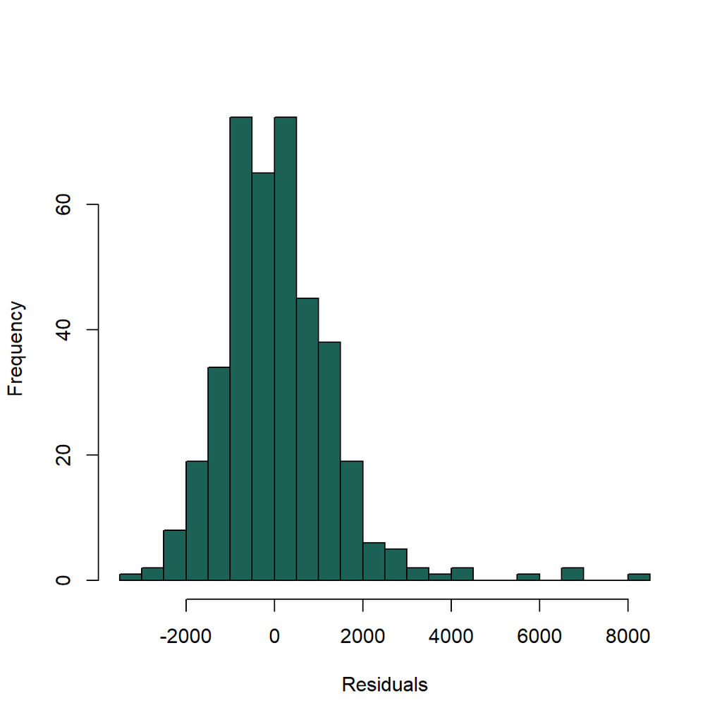

```r
hist(all.residuals, breaks = 25, xlab = "Residuals", main = "", col = "#1c6155")
```

> We can the residuals of our predictions on the validation set. The Spread is clearly visible, between -2000 and 2000 and normally distributed. Some extremes values for our residuals appear on the far right,.

# Ex 9.3

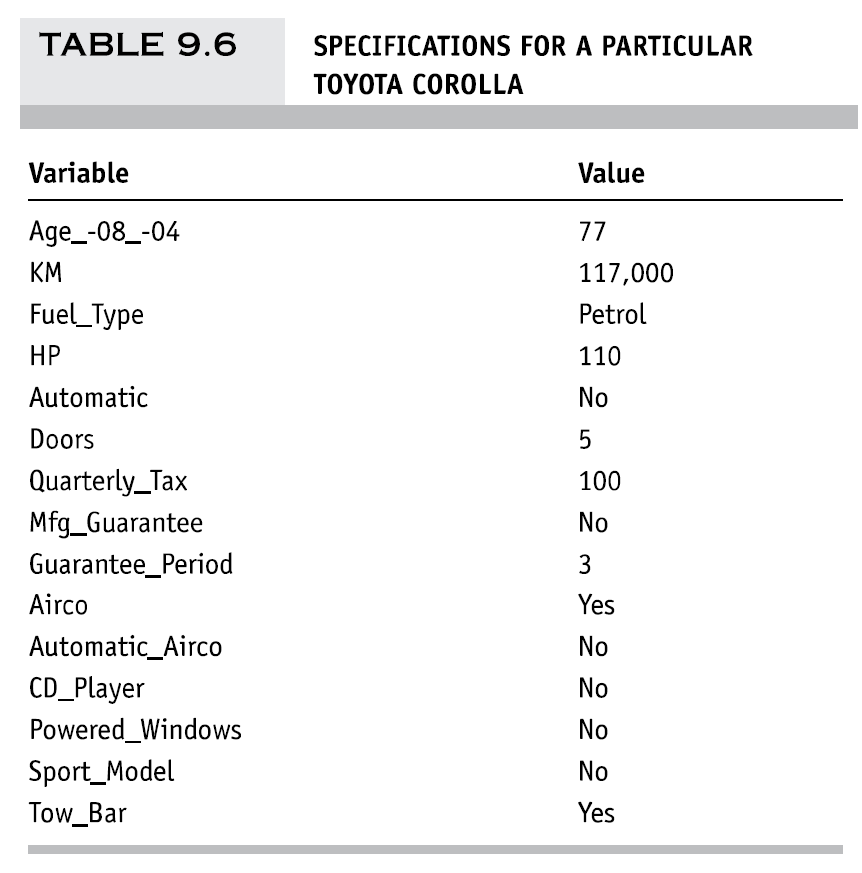

# Ex 11.3

## Car Sales

The Goal is to predict the price of a used Toyota Corolla based on its specifications.

### a. Fit a neural network model to the data. Use a single hidden layer with 2 nodes.

Use predictors **Age_08_04**, **KM**, **Fuel_Type**, **HP**, **Automatic**, **Doors**, **Quarterly_Tax**, **Mfr_Guarantee**, **Guarantee_Period**, **Airco**, **Automatic_airco**, **CD_Player**, **Powered_Windows**, **Sport_Model**, and **Tow_Bar**.

### Splitting Training and Validation Set - 60% VS 40%

```r
# Reproducible Results
set.seed(1)

# required Packages
library(neuralnet)
library(nnet)
library(caret)

# Load the Dataset with Fread()
ToyotaDT_NN <- fread("DATA/ToyotaCorolla.csv")

# Select the 15 variables
ToyotaDT_NN <- ToyotaDT_NN[,c("Price","Age_08_04","KM","Fuel_Type","HP","Automatic","Doors","Quarterly_Tax","Mfr_Guarantee","Guarantee_Period","Airco","Automatic_airco","CD_Player","Powered_Windows","Sport_Model","Tow_Bar")]

# Input Cutting Ratio
probability_train <- 0.6
probability_test <- 1 - probability_train

# Training and Validation Set Splitting
sample <- sample(c(TRUE, FALSE), nrow(ToyotaDT_NN), replace=TRUE, prob=c(probability_train,probability_test))
Train_NN  <- ToyotaDT_NN[sample, ]
Test_NN   <- ToyotaDT_NN[!sample, ]

# Proportions Check
Prop_Training <- nrow(Train_NN)/nrow(ToyotaDT_NN)*100
Prop_Validation <- nrow(Test_NN)/nrow(ToyotaDT_NN)*100

# Preprocess Variables - 8 Dummies - Fuel Type to Dummy - 7 Numerical

## create dummies for fuel type
Fuel_Type <- as.data.frame(model.matrix(~ 0 + Fuel_Type, data=Train_NN))

## replace Fuel_Type column with 2 dummies
Train_NN <- cbind(Train_NN[,-c("Fuel_Type")], Fuel_Type[,])

## replace Fuel_Type column with 2 dummies
Test_NN <- cbind(Test_NN[,-c("Fuel_Type")], Fuel_Type[,])

## Numerical Processing with Training Set
preProcValues <- preProcess(Train_NN[,c("Price","Age_08_04","KM","HP","Doors","Quarterly_Tax","Guarantee_Period")], method = "range")

## Preprocess the Training Set
Train_NN_Preprocess <- predict(preProcValues, Train_NN)

## Preprocess the Test Set
Test_NN_Preprocess <- predict(preProcValues, Test_NN)

# Print Proportions

print(paste(round(Prop_Training,2),"% In Training", round(Prop_Validation,2),"% In Validation"))
```

```
FALSE [1] "61.42 % In Training 38.58 % In Validation"
```

### Neural Network A - 1 Hidden Layers with 2 Nodes

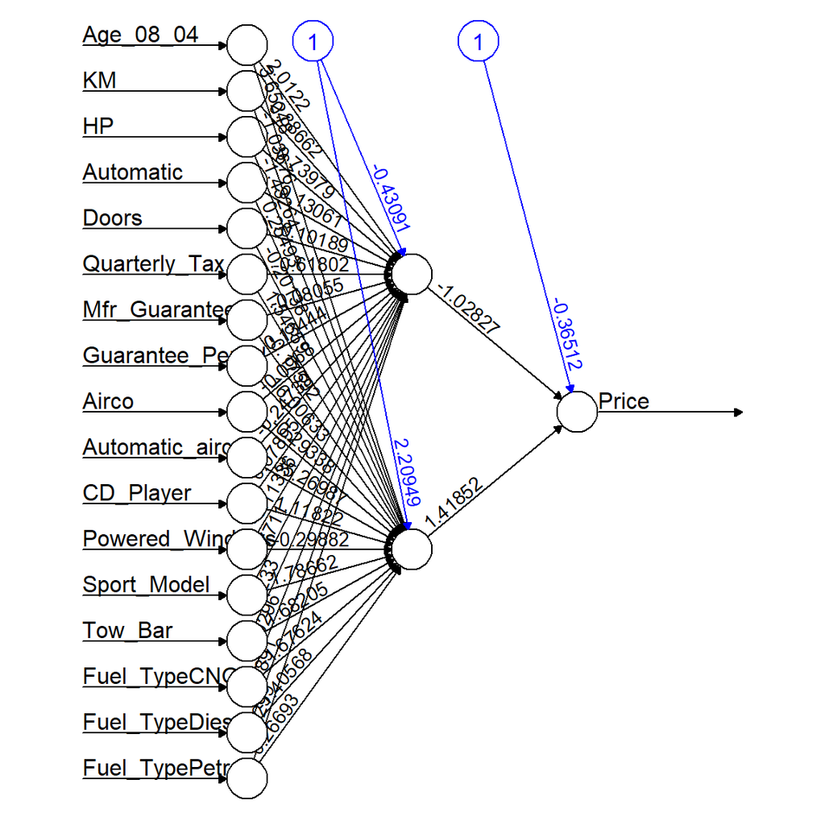

```r
# Reproducible Results
set.seed(1)

nn_1 <- neuralnet(Price ~ ., data = Train_NN_Preprocess, linear.output = T, hidden = 2)

plot(nn_1, rep="best")
```

### Weights of the Neural Network A

```r
# display weights
nn_1$weights
```

```
FALSE [[1]]
FALSE [[1]][[1]]
FALSE          [,1]   [,2]
FALSE  [1,] -0.4309  2.209
FALSE  [2,]  2.0122  3.652
FALSE  [3,]  0.8866 -1.037
FALSE  [4,] -0.7398 -1.433
FALSE  [5,] -0.1306  0.255
FALSE  [6,] -0.1019 -0.201
FALSE  [7,] -0.6180  1.546
FALSE  [8,] -0.0805 -0.176
FALSE  [9,]  0.1344 16.006
FALSE [10,] -0.0968 -0.293
FALSE [11,] -0.2474 35.270
FALSE [12,]  0.0789  1.118
FALSE [13,] -0.1134 -0.299
FALSE [14,]  0.0771  1.787
FALSE [15,]  0.1233  1.682
FALSE [16,]  0.7030 -1.676
FALSE [17,]  0.5789 -1.406
FALSE [18,]  0.7630  0.267
FALSE
FALSE [[1]][[2]]
FALSE        [,1]
FALSE [1,] -0.365
FALSE [2,] -1.028
FALSE [3,]  1.419
```

### Neural Network B - 1 Hidden Layers with 5 Nodes

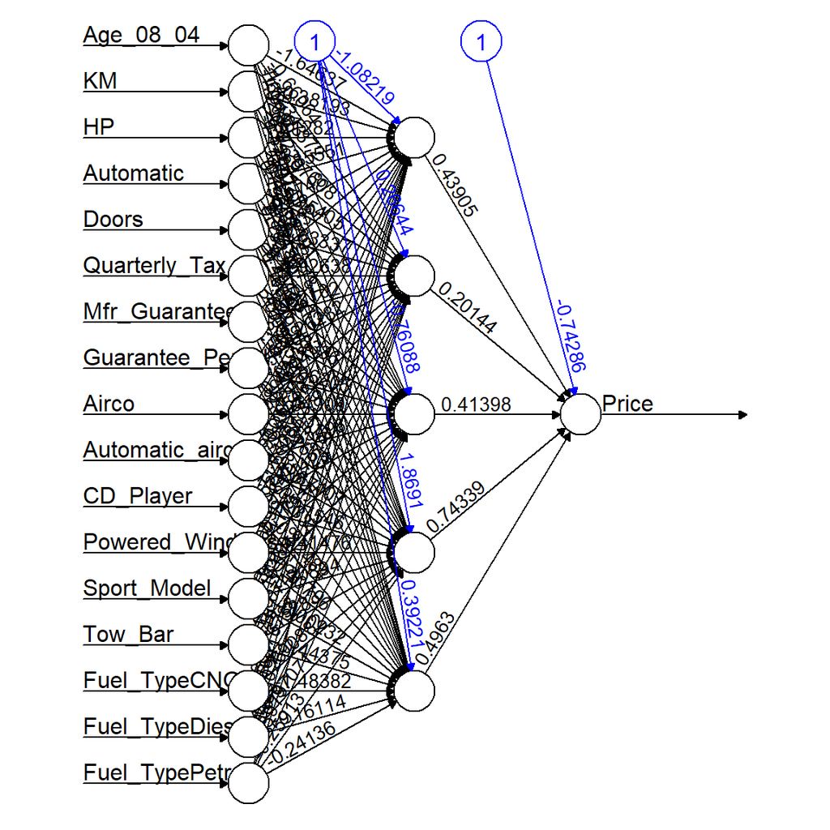

```r
# Reproducible Results
set.seed(1)

nn_2 <- neuralnet(Price ~ ., data = Train_NN_Preprocess, linear.output = T, hidden = 5)

plot(nn_2, rep="best")
```

### Weights of the Neural Network B

```r
# display weights
nn_2$weights
```

```
FALSE [[1]]
FALSE [[1]][[1]]
FALSE          [,1]     [,2]    [,3]   [,4]     [,5]
FALSE  [1,] -1.0822   0.2664 -0.7609  1.869  0.39221
FALSE  [2,] -1.6464  -0.6606 -1.4234  1.682 -1.92659
FALSE  [3,] -0.3819   0.6737 -0.8228 -0.520 -1.17504
FALSE  [4,]  1.1282  -0.0761  0.9746 -0.426  0.19693
FALSE  [5,] -0.8555  -5.9541  0.8139  2.845  0.15236
FALSE  [6,] -0.2748  -0.8334  0.4679  0.254  0.16805
FALSE  [7,]  0.0783  -4.9264  1.6873  2.500 -0.09956
FALSE  [8,]  0.4218   0.6210  0.2834 -0.246 -0.39992
FALSE  [9,]  1.3905 -35.2628 -1.0621 18.735 -0.72520
FALSE [10,]  0.0566   0.4204  0.0491 -0.165  0.08564
FALSE [11,]  1.2989   4.3655 -0.5550 -0.871  0.03334
FALSE [12,] -0.2900  -1.4439  1.0142  1.175 -0.82484
FALSE [13,] -0.1653   1.9985  0.1753 -1.415  0.40796
FALSE [14,] -0.3060 -91.3117  0.2948  2.309 -0.00232
FALSE [15,]  0.2535 -78.1617 -0.0750  2.528 -0.44375
FALSE [16,]  1.1113   1.3446 -1.7674 -1.909 -1.48382
FALSE [17,]  0.5031  -1.6160 -1.2026 -0.971 -0.16114
FALSE [18,]  0.4911  -1.0049 -1.5398 -0.259 -0.24136
FALSE
FALSE [[1]][[2]]
FALSE        [,1]
FALSE [1,] -0.743
FALSE [2,]  0.439
FALSE [3,]  0.201
FALSE [4,]  0.414
FALSE [5,]  0.743
FALSE [6,]  0.496
```

### Neural Network C - 2 Hidden Layers with 5 Nodes in each

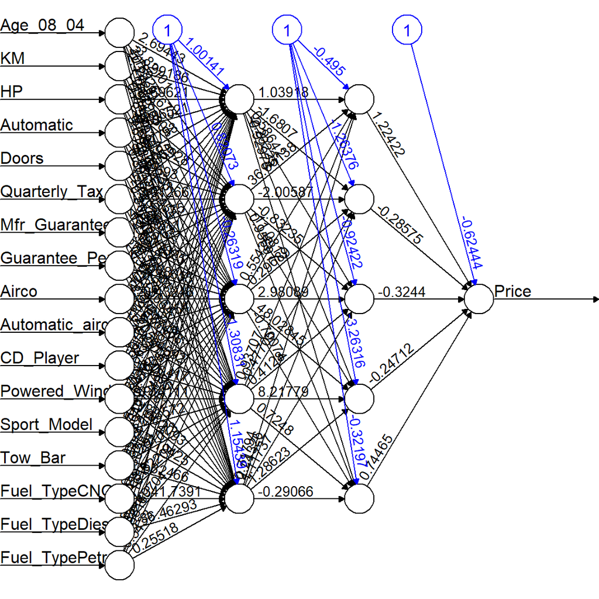

```r
# Reproducible Results
set.seed(1)

nn_3 <- neuralnet(Price ~ ., data = Train_NN_Preprocess, linear.output = T, hidden = c(5,5))

plot(nn_3, rep="best")
```

### Weights of the Neural Network C

```r
# display weights
nn_3$weights
```

```
FALSE [[1]]
FALSE [[1]][[1]]
FALSE          [,1]    [,2]   [,3]   [,4]     [,5]
FALSE  [1,]  1.0014  0.8207 -0.263 -1.308    1.154
FALSE  [2,]  2.6944 -3.8210  2.189 10.242   -2.117
FALSE  [3,]  1.9919 -1.8167  0.679 -1.140    0.783
FALSE  [4,]  2.6962  1.9304 -0.935 -5.662    9.611
FALSE  [5,] -2.0652 -0.1293 -0.492  1.182    0.806
FALSE  [6,]  0.0779 -0.6930 -1.155 -0.298   -0.300
FALSE  [7,] -5.3986  3.0127  1.366  4.488   12.672
FALSE  [8,]  2.3418  0.8618  0.378 -0.762    0.396
FALSE  [9,] -3.7351 -1.2264 -1.887 33.366   -3.809
FALSE [10,] -1.1707 -0.2756 -0.432 -1.375   -2.054
FALSE [11,] -5.5473 -0.0329 -0.332  4.946   -2.549
FALSE [12,]  1.0162  0.2500  0.318  3.204    6.706
FALSE [13,] -0.8608  0.4563  0.167  0.141   19.021
FALSE [14,] -4.3215 -0.0348  0.619  1.386   -1.194
FALSE [15,]  0.3951  0.1364  0.283  0.611    4.325
FALSE [16,] -2.9950 -3.3677 -0.303 -3.822 -341.739
FALSE [17,]  4.2604 -3.1110 -2.016 -5.497  -36.463
FALSE [18,]  0.9853 -0.4030 -0.868  0.543    0.255
FALSE
FALSE [[1]][[2]]
FALSE        [,1]   [,2]   [,3]   [,4]   [,5]
FALSE [1,] -0.495 -1.264 -0.924  -3.26 -0.322
FALSE [2,]  1.039 -1.681  0.586  -2.20 -0.930
FALSE [3,] 36.661 -2.006 -0.832 -11.08  0.957
FALSE [4,]  0.554  0.297  2.981  48.03 -0.701
FALSE [5,]  0.937 -0.477  0.413   8.22  0.725
FALSE [6,]  0.718  2.243  1.117   1.29 -0.291
FALSE
FALSE [[1]][[3]]
FALSE        [,1]
FALSE [1,] -0.624
FALSE [2,]  1.224
FALSE [3,] -0.286
FALSE [4,] -0.324
FALSE [5,] -0.247
FALSE [6,]  0.745
```

### Predictions and RMSE

#### RMSE For Training Set

```r
# Preprocess Scale - Range Method ----------------------------

# Predictions for Training -----------------------------------

# Predictions with nn
Train_Prediction_nn_1 <- predict(nn_1,Train_NN_Preprocess)

# Predictions with nn_2
Train_Prediction_nn_2 <- predict(nn_2,Train_NN_Preprocess)

# Predictions with nn_3
Train_Prediction_nn_3 <- predict(nn_3,Train_NN_Preprocess)

# Back transform to Original Scale ---------------------------

# Predictions with nn
Train_Prediction_nn_1 <- Train_Prediction_nn_1*(max(Train_NN$Price)-min(Train_NN$Price))+min(Train_NN$Price)

# Predictions with nn_2
Train_Prediction_nn_2 <- Train_Prediction_nn_2*(max(Train_NN$Price)-min(Train_NN$Price))+min(Train_NN$Price)

# Predictions with nn_3
Train_Prediction_nn_3 <- Train_Prediction_nn_3*(max(Train_NN$Price)-min(Train_NN$Price))+min(Train_NN$Price)

# RMSE for Train  -------------------------------------------------------

RMSE_Train_Prediction_nn_1 <- RMSE(Train_Prediction_nn_1,Train_NN$Price)
RMSE_Train_Prediction_nn_2 <- RMSE(Train_Prediction_nn_2,Train_NN$Price)
RMSE_Train_Prediction_nn_3 <- RMSE(Train_Prediction_nn_3,Train_NN$Price)

RMSE <- c(RMSE_Train_Prediction_nn_1,RMSE_Train_Prediction_nn_2,RMSE_Train_Prediction_nn_3)

# Rounding RMSE
RMSE <- round(RMSE,2)

# Adding Name to Model
Model <- c("Neural A: 1 Hidden Layer, 2 Nodes","Neural B: 1 Hidden Layer, 5 Nodes", "Neural C: 2 Hidden Layer, 5 Nodes")

Frame_RMSE <- cbind(Model,RMSE)
Frame_RMSE <- as.data.frame(Frame_RMSE)

RMSE_DATA <- flextable(Frame_RMSE) %>% fontsize(size = 8, part = "all")

(RMSE_DATA)
```

| Model | RMSE |
| --- | --- |
| Neural A: 1 Hidden Layer, 2 Nodes | 984.02 |
| Neural B: 1 Hidden Layer, 5 Nodes | 937.9 |
| Neural C: 2 Hidden Layer, 5 Nodes | 857.48 |

#### RMSE For Validation Set

```r
# Predictions for Validation --------------------------------

# Predictions with nn
Validation_Prediction_nn_1 <- predict(nn_1,Test_NN_Preprocess)

# Predictions with nn_2
Validation_Prediction_nn_2 <- predict(nn_2,Test_NN_Preprocess)

# Predictions with nn_3
Validation_Prediction_nn_3 <- predict(nn_3,Test_NN_Preprocess)

# Back transform to Original Scale ---------------------------

# Predictions with nn
Validation_Prediction_nn_1 <- Validation_Prediction_nn_1*(max(Train_NN$Price)-min(Train_NN$Price))+min(Train_NN$Price)

# Predictions with nn_2
Validation_Prediction_nn_2 <- Validation_Prediction_nn_2*(max(Train_NN$Price)-min(Train_NN$Price))+min(Train_NN$Price)

# Predictions with nn_3
Validation_Prediction_nn_3 <- Validation_Prediction_nn_3*(max(Train_NN$Price)-min(Train_NN$Price))+min(Train_NN$Price)

# RMSE for Validation  -------------------------------------------------------

RMSE_Validation_Prediction_1 <- RMSE(Validation_Prediction_nn_1, Test_NN$Price)
RMSE_Validation_Prediction_2 <- RMSE(Validation_Prediction_nn_2, Test_NN$Price)
RMSE_Validation_Prediction_3 <- RMSE(Validation_Prediction_nn_3, Test_NN$Price)

RMSE_Validation <- c(RMSE_Validation_Prediction_1,RMSE_Validation_Prediction_2,RMSE_Validation_Prediction_3)

# Rounding RMSE
RMSE_Validation <- round(RMSE_Validation,2)

# Adding Name to Model
Model <- c("Neural A: 1 Hidden Layer, 2 Nodes","Neural B: 1 Hidden Layer, 5 Nodes", "Neural C: 2 Hidden Layer, 5 Nodes")

Frame_RMSE_Validation <- cbind(Model,RMSE_Validation)
Frame_RMSE_Validation <- as.data.frame(Frame_RMSE_Validation)

RMSE_VALIDATION_DATA <- flextable(Frame_RMSE_Validation) %>% fontsize(size = 8, part = "all")
RMSE_VALIDATION_DATA <- set_header_labels(RMSE_VALIDATION_DATA, RMSE_Validation = "RMSE")

(RMSE_VALIDATION_DATA)
```

| Model | RMSE |
| --- | --- |
| Neural A: 1 Hidden Layer, 2 Nodes | 1483.17 |
| Neural B: 1 Hidden Layer, 5 Nodes | 1413.01 |
| Neural C: 2 Hidden Layer, 5 Nodes | 1642.87 |

#### i. What happens to the RMS error for the training data as the number of layers and nodes increases ?

> RMSE tend to decrease the more when complexify our neural network (Model C in that case). This indicates we are overfitting more and more our model to the training dataset.

#### ii. What happens to the RMS error for the validation data?

> The RMSE for the Validation Data is lower for the Neural Model B, and then it increases with the model C.

#### iii. Comment on the appropriate number of layers and nodes for this application.

> Model A and B are close, but Model A is not in a overfitting situation, we should decide wether we prefer good predictions with Model B and more overfitting to the training dataset, or Model A which give less accurate result but with more stability in future predictions since it is not overfitting such as Model C. In this case, I would prefer the Model B giving more accurate results but more prone to instability, thus choosing 1 Hidden Layers with 5 Nodes.

# References

[Github Repo for this Homework 3](https://github.com/LiamPhan17/DATA_MINING_HW3)

[Data Mining for Business Analytics: Concepts, Techniques, and Applications in R](https://www.wiley.com/en-us/Data+Mining+for+Business+Analytics:+Concepts,+Techniques,+and+Applications+in+R-p-9781118879368)

[Summarytools in R Markdown Documents](https://cran.r-project.org/web/packages/summarytools/vignettes/rmarkdown.html)

[Data Science Plus - Fitting Neural Network in R](https://datascienceplus.com/fitting-neural-network-in-r/)

[Backtransform with the Caret Package and Preprocess() Function](https://www.tradersinsight.news/ibkr-quant-news/r-code-back-transform-from-carets-preprocess/)